# K-means clustering

```r
#Summary statistics for Private

set.seed(123)
summary_Private <-Mydata_all%>%
  filter(Public..1...Private..2. == 2) %>% group_by(cluster_dist)  %>% summarise( Private=sum(Public..1...Private..2.==2),AcceptanceRate = sum(X..appl..accepted)/ sum(X..appli..rec.d),new_mean=mean(X..new.stud..enrolled),top10_mean=mean(X..new.stud..from.top.10.),top25_mean=mean(X..new.stud..from.top.25.),out_state_mean=mean(out.of.state.tuition), in_state_mean=mean(in.state.tuition), PHD_mean=mean(X..fac..w.PHD), studfac_mean=mean(stud..fac..ratio), gradustio_mean=mean(Graduation.rate))
head(summary_Private)
```

```
## # A tibble: 3 x 11
##   cluster_dist Private AcceptanceRate new_mean top10_mean top25_mean
##          <int>   <int>          <dbl>    <dbl>      <dbl>      <dbl>
## 1            1      12          0.716    1650.       24.2       56.2
## 2            2     110          0.557     715.       49.7       78.0
## 3            3     221          0.782     309.       21.7       48.5
## # ... with 5 more variables: out_state_mean <dbl>, in_state_mean <dbl>,
## #   PHD_mean <dbl>, studfac_mean <dbl>, gradustio_mean <dbl>
```

```r
#Summary statistics for Public

set.seed(123)
summary_Public <-Mydata_all%>%
  filter(Public..1...Private..2. == 1) %>% group_by(cluster_dist)  %>% summarise(Public=sum(Public..1...Private..2.== 1),  AcceptanceRate = sum(X..appl..accepted)/ sum(X..appli..rec.d),new_mean=mean(X..new.stud..enrolled),top10_mean=mean(X..new.stud..from.top.10.),top25_mean=mean(X..new.stud..from.top.25.),out_state_mean=mean(out.of.state.tuition), in_state_mean=mean(in.state.tuition), PHD_mean=mean(X..fac..w.PHD), studfac_mean=mean(stud..fac..ratio), gradustio_mean=mean(Graduation.rate))
head(summary_Public)
```

```
## # A tibble: 3 x 11
##   cluster_dist Public AcceptanceRate new_mean top10_mean top25_mean
##          <int>  <int>          <dbl>    <dbl>      <dbl>      <dbl>
## 1            1     99          0.678    1885.       21.4       50.6
## 2            2      3          0.385    1415.       61.3       85
## 3            3     26          0.728     391.       13.0       37.1
## # ... with 5 more variables: out_state_mean <dbl>, in_state_mean <dbl>,
## #   PHD_mean <dbl>, studfac_mean <dbl>, gradustio_mean <dbl>
```

```r
#table for public and public in each cluster
table(Mydata_all$Public..1...Private..2.,Mydata_all$cluster_dist)
```

```
##
##       1   2   3
##   1  99   3  26
##   2  12 110 221
```

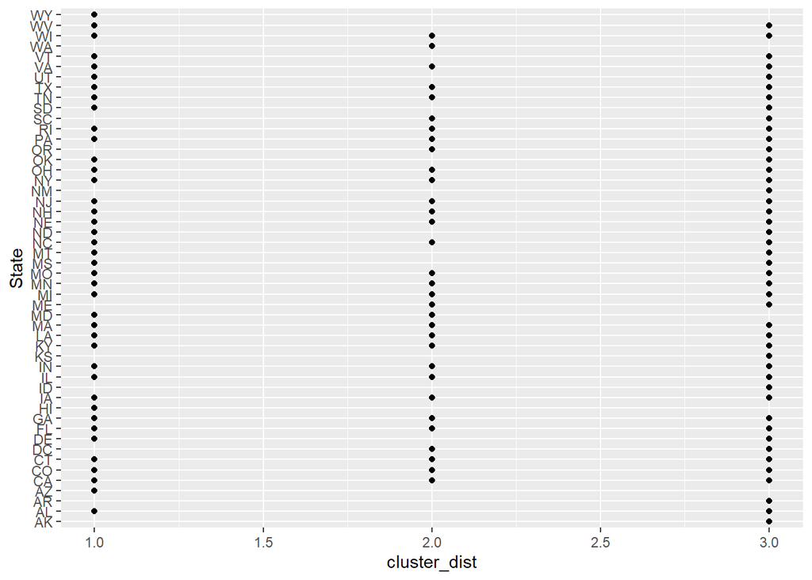

```r
#Data visualization
library(ggplot2)

#states vs clusters plot
ggplot(Mydata_all,aes(x= cluster_dist,y = State))+geom_point()
```

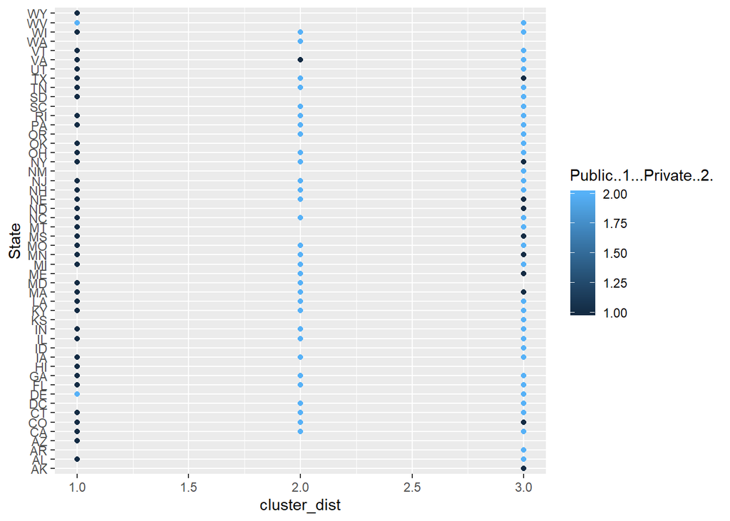

```r
#states in terms of Public..1...Private..2. vs clusters
ggplot(Mydata_all,aes(x= cluster_dist,y = State, color = Public..1...Private..2. ))+geom_point()
```

```r
#Public and private universities(categorical variables) has relationship in analysis the data and also provide insightfulness when analyzing  the clusters.
```

5. What other external information can explain the contents of some or all of these clusters? External information like having more data,also more variables like neighbourhood crime rate,financial,academic reputation.
6. Consider Tufts University, which is missing some information. Compute the Euclidean distance of this record from each of the clusters that you found above (using only the measurements that you have). Which cluster is it closest to? Impute the missing values for Tufts by taking the average of the cluster on those measurements.

```r
k3 <- kmeans(Mydata1_norm, centers = 3, nstart = 25 )


Tufts <- filter(Mydata, College.Name == "Tufts University")
#Euclidean distance  from Cluster 1
dist(rbind(Tufts[, -c(1, 2, 3,10)], k3$centers[1,]))
```

```
##          1
## 2 29816.76
```

```r
#Euclidean distance  from Cluster 2
dist(rbind(Tufts[, -c(1, 2, 3,10)], k3$centers[2,]))
```

```
##         1
## 2 29817.8
```

```r
#Euclidean distance  from Cluster 3
dist(rbind(Tufts[, -c(1, 2, 3,10)], k3$centers[3,]))
```

```
##          1
## 2 29819.09
```

```r
#Imputing missing values
cluster_Tufts <- filter(Mydata_all, cluster_dist == 1)
cluster_Mean <- mean(cluster_Tufts[,c(10)])
Tufts[, c(10)] <- cluster_Mean
cluster_Mean
```

```
## [1] 2260.721
```